# Assignment 2

```r
library(dplyr)
library(ggplot2)
# Loading data
data(CPS85, package = "mosaicData")

df <- CPS85 %>%
  group_by(sector, sex) %>%
  summarise(n = n())
print(df)
```

```
## # A tibble: 15 × 3
## # Groups:   sector [8]
##    sector   sex       n
##    <fct>    <fct> <int>
##  1 clerical F        76
##  2 clerical M        21
##  3 const    M        20
##  4 manag    F        21
##  5 manag    M        34
##  6 manuf    F        24
##  7 manuf    M        44
##  8 other    F         6
##  9 other    M        62
## 10 prof     F        52
## 11 prof     M        53
## 12 sales    F        17
## 13 sales    M        21
## 14 service  F        49
## 15 service  M        34
```

Q1: Construct a stacked bar chart to show the number of females and males in each sectors.

Hint: `geom_text()` may help you show the numbers in the bars. The two color values `#C73C68` and `#B6C468` can help.

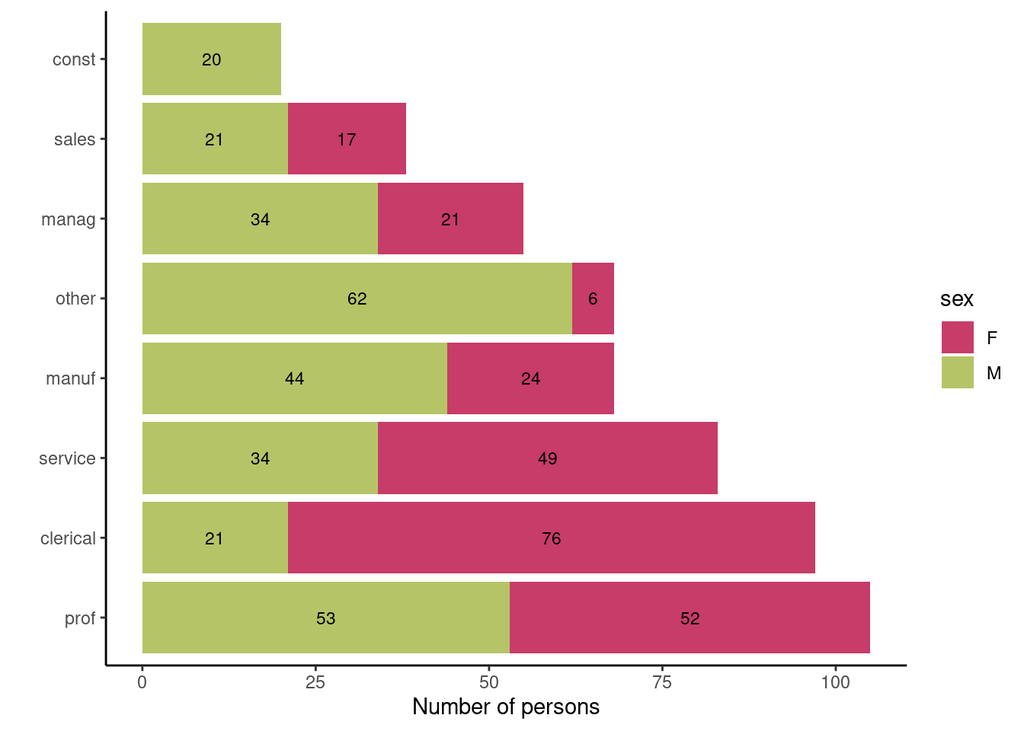

```r
ggplot(df, aes(y = reorder(sector, n, sum, decreasing = TRUE), x = n, fill = sex)) +
  geom_bar(stat = "identity") +
  geom_text(aes(label = n), position = position_stack(vjust = 0.5), color = "black", size = 3) +
  labs(
    x = "Number of persons",
    y = ""
  ) +
  scale_fill_manual(values = c("F" = "#C73C68", "M" = "#B6C468")) +
  theme_classic()
```

Q2: Based on the dataset `SaratogaHouses` from package `mosaicData`, please draw a scatterplot for house ages and prices with quadratic line of best fit.

Hint: `geom_smooth()` may help you to construct the linear regression line. You can specify the points with `size = 1`, `alpha = 0.4`, the fitting line with `size = 0.5`, `color = "tomato"`.

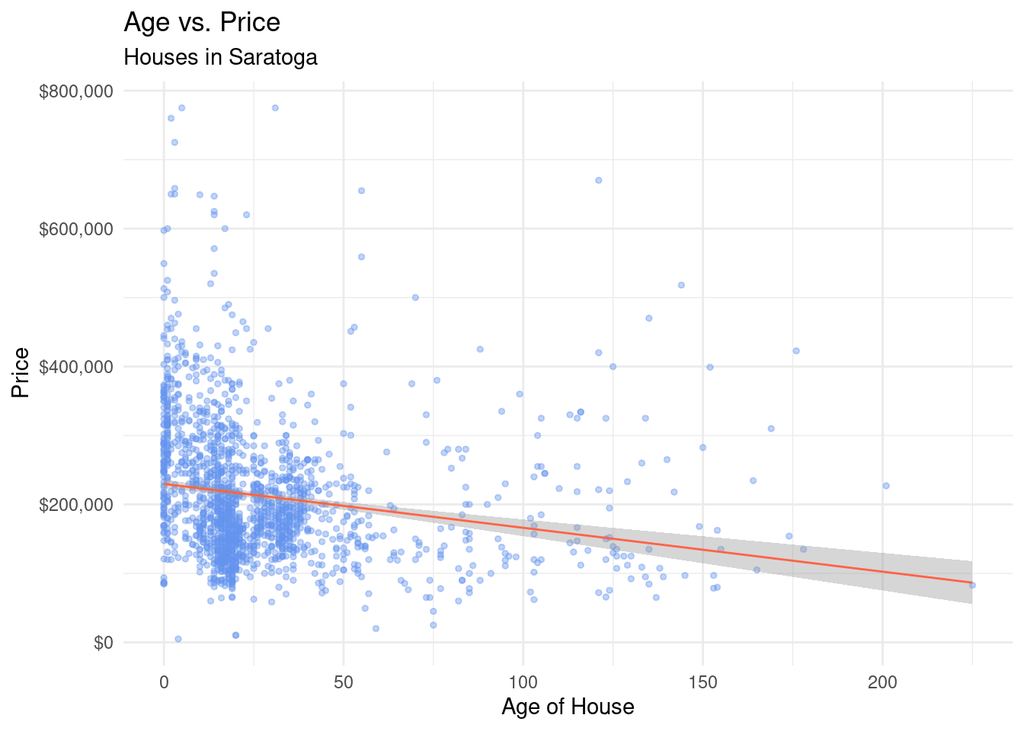

```r
library(mosaicData)
data(SaratogaHouses)

ggplot(SaratogaHouses, aes(x = age, y = price)) +
  geom_point(size = 1, alpha = 0.4, color = "cornflowerblue") +
  geom_smooth(method = "lm", formula = y ~ poly(x, 1), se = TRUE, size = 0.5, color = "tomato") +
  labs(
    title = "Age vs. Price",
    subtitle = "Houses in Saratoga",
    x = "Age of House",
    y = "Price"
  ) +
  scale_y_continuous(labels = scales::dollar_format()) +
  theme_minimal()
```

Q3: Based on the dataset `SaratogaHouses` from package `mosaicData`, please draw the boxplot for the house price by number of rooms.

Hint: Transparency of boxplot is specified as `alpha = 0.5`.

```
## Notch went outside hinges
## ℹ Do you want `notch = FALSE`?
```

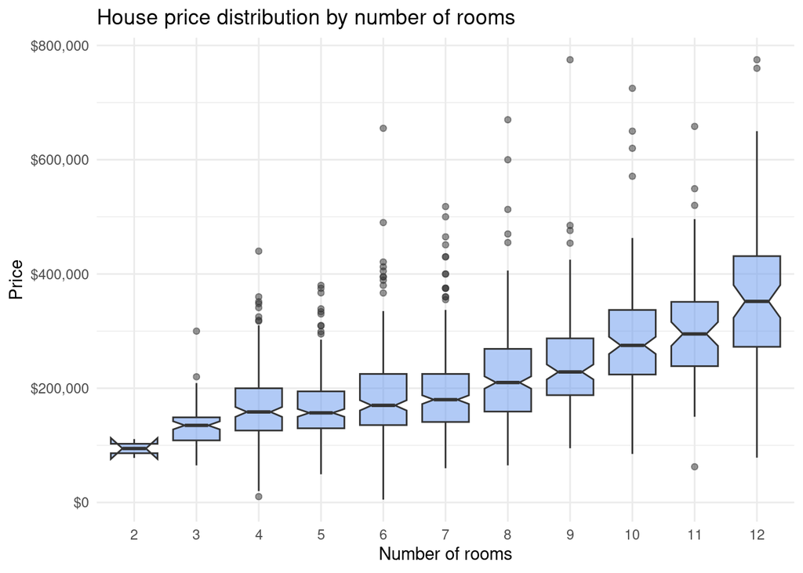

```r
# Create a boxplot for house prices by the number of rooms
ggplot(SaratogaHouses, aes(x = factor(rooms), y = price)) +
  geom_boxplot(alpha = 0.5, notch = TRUE, fill = "cornflowerblue") +
  labs(
    title = "House price distribution by number of rooms",
    x = "Number of rooms",
    y = "Price"
  ) +
  scale_y_continuous(labels = scales::dollar_format()) +
  theme_minimal()
```

Q4: Please plot the Cleveland dot chart for the percentage of receipts in GDP by country. The datasset `newgdp` from the package `CGPfunctions` records current receipts of fifteen national governments as a percentage of gross domestic product. You can read more detail by running the code `??newgdp` in the console.

Hint: Please install the package CGPfunctions if you haven’t installed. (No need to write the install code in the R code chunk below.) The range of x is (0.2, 0.6).

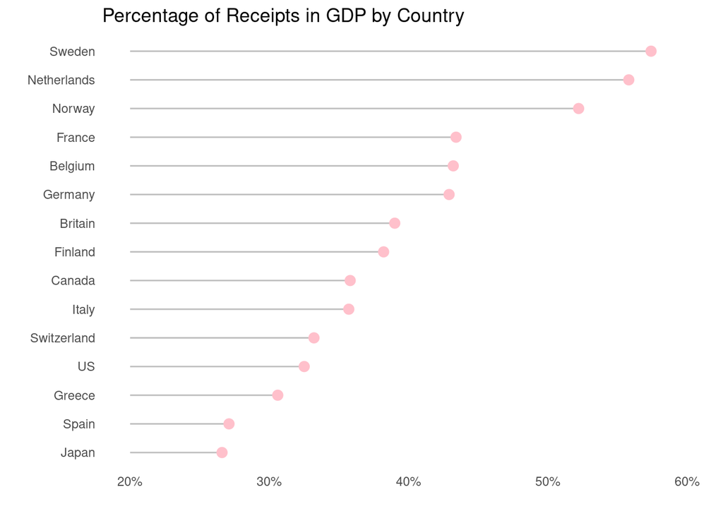

```r
data(newgdp, package = "CGPfunctions")

df <- newgdp %>%
  filter(Year == "Year1979") %>%
  mutate(GDP = GDP / 100)

ggplot(df, aes(
  x = GDP,
  y = reorder(Country, GDP)
)) +
  geom_segment(
    aes(
      x = 0.2,
      xend = GDP,
      y = reorder(Country, GDP),
      yend = Country
    ),
    color = "grey"
  ) +
  geom_point(color = "pink", size = 3) +
  scale_x_continuous(labels = scales::percent_format()) +
  labs(
    x = "",
    y = "",
    title = "Percentage of Receipts in GDP by Country"
  ) +
  coord_cartesian(xlim = c(0.2, 0.6)) +
  theme_light() +
  theme(
    panel.grid.major = element_blank(),
    panel.grid.minor = element_blank(),
    panel.border = element_blank(),
    panel.background = element_blank(),
    axis.ticks.y = element_blank(),
    axis.ticks.x = element_blank()
  )
```

Q5 A tiny project

The data file `Real-Estate.txt` contains information on the homes sold in the Denver area during the year 2003.

|  | Description |
| --- | --- |
| Price | Selling price in $1000 |
| Bedrooms | Number of bedrooms |
| Size | Size of the home in square feet |
| Pool | Whether having a swimming Pool (yes or no) |
| Distance | Distance from the home to the center of the city |
| Township | Township No. |
| Garage | Whether is garage attached (yes or no) |
| Baths | Number of bathrooms |

1. Please analyze the data and abstract at least 2 tasks.
2. Design your visualization according to the design principles and give your justification. Please write your design thoughts clearly.
3. Implement your visualization by R. Please write the annotations for each step.

## Analyze:

The data set have the shape of 105 rows and 8 columns, including 2 categorical feature and 6 numerical feature.

Base on the data set, we can abstract the following tasks:

- How the number of rooms affect the price of the properties?
- What impact does the presence of a garage have on the price?
- Find out the relationship between the price and other variables
- Find the distribution of number of rooms over Pool and Garage

Before the data visualization, let’s do the data preprocessing

```r
# Data Preprocessing: Convert Pool and Garage to categorical data
df <- read.table("Real-Estate.txt", header = TRUE) %>%
  mutate(Pool = ifelse(Pool == 1, "With Pool", "Without Pool")) %>%
  mutate(Garage = ifelse(Garage == 1, "With Garage", "Without Garage")) %>%
  mutate(Price = Price * 1000) # align the price
```

## Number of rooms V.S. Price

**Design Thoughts:**

- **Visual Element:** A boxplot is suitable for comparing the distribution of property prices for different numbers of rooms.
- **X-axis:** Number of rooms (Bedrooms).
- **Y-axis:** Property Prices.
- **Justification:** Box plots are effective for displaying the central tendency, spread, and potential outliers in a data set. They are particularly useful for comparing the distribution of a numerical variable (price) across different categories (number of rooms).

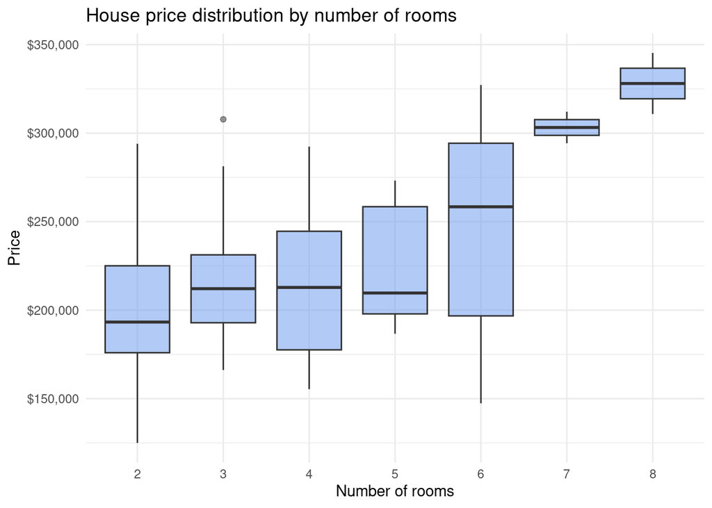

```r
ggplot(df, aes(x = factor(Bedrooms), y = Price)) +
  geom_boxplot(alpha = 0.5, notch = F, fill = "cornflowerblue") + # use boxplot
  labs(
    title = "House price distribution by number of rooms",
    x = "Number of rooms",
    y = "Price"
  ) + # set labels
  scale_y_continuous(labels = scales::dollar_format()) +
  theme_minimal()
```

From the box plot we can notice that as number of rooms grows larger, the properties usually can sell a higher price.

### How Garage affect the price of the room

**Design Thoughts:**

- **Visual Element:** A density plot is suitable for illustrating the distribution of property prices based on the presence or absence of a garage.
- **X-axis:** Property Prices.
- **Fill (Color):** Presence or absence of a garage.
- **Justification:** Density plots are effective for showing the distribution of a continuous variable (price) and understanding how it varies across different categories (presence or absence of a garage).

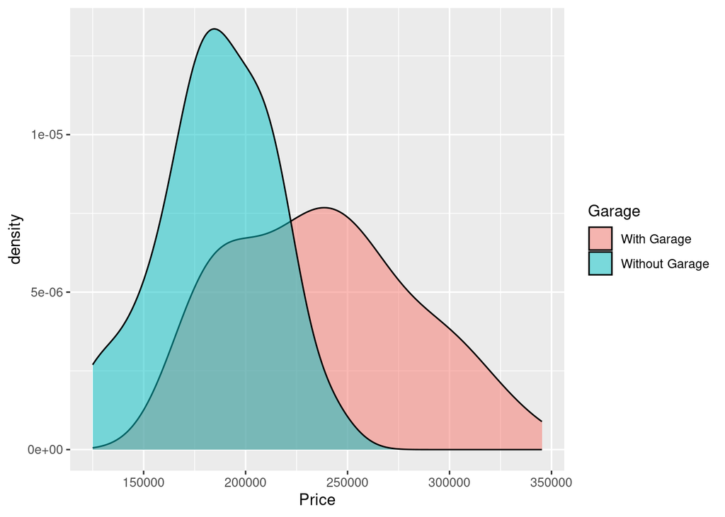

```r
ggplot(df, aes(x = Price, fill = Garage)) +
  geom_density(alpha = 0.5)
```

From the graph we can obtain that when the garage presence, property usually can sell a higher price.

### What’s the relationship between the price and other variables

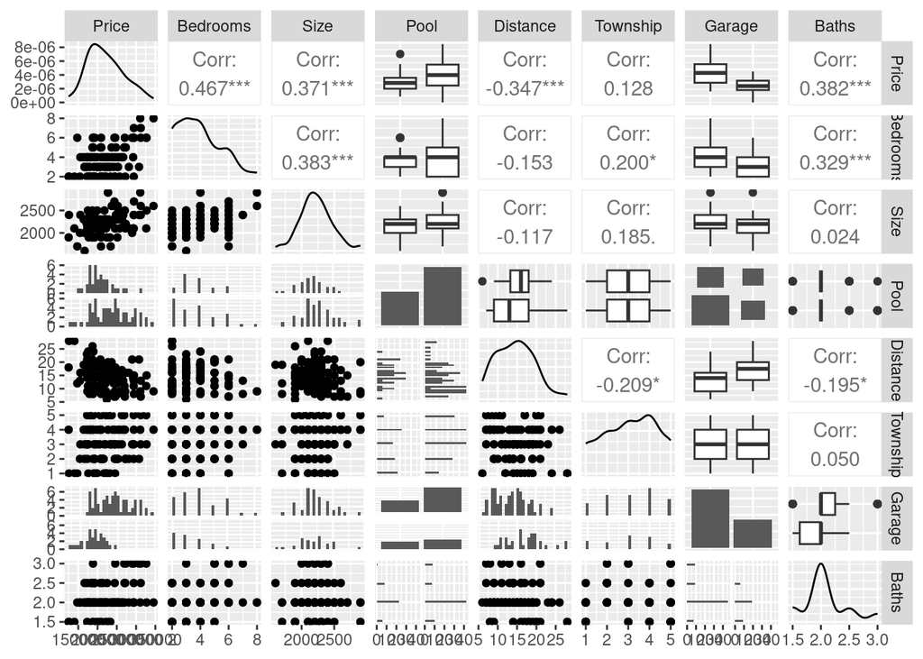

```r
library(GGally)
ggpairs(df)
```

From the graph we can notice that the presence of garage and the number of bedrooms contribute a lot to the price of the property, and the price is also positive correlated to the size of the room and **negative** correlated to the distance to center of the city.

### Distribution of Rooms

**Design Thoughts:**

- **Visual Element:** A stacked bar plot is chosen to represent the percentage distribution of each number of rooms, with segments indicating the presence or absence of a pool and garage.
- **X-axis:** Number of Rooms.
- **Y-axis:** Percentage.
- **Hue (Fill):** Stacked segments represent the breakdown of Pool and Garage.

```r
# Data Preprocessing
room_percentage <- df %>%
  group_by(Bedrooms, Pool, Garage) %>%
  summarise(Count = n()) %>%
  group_by(Bedrooms) %>%
  mutate(Percentage = (Count / sum(Count)) * 100)
```

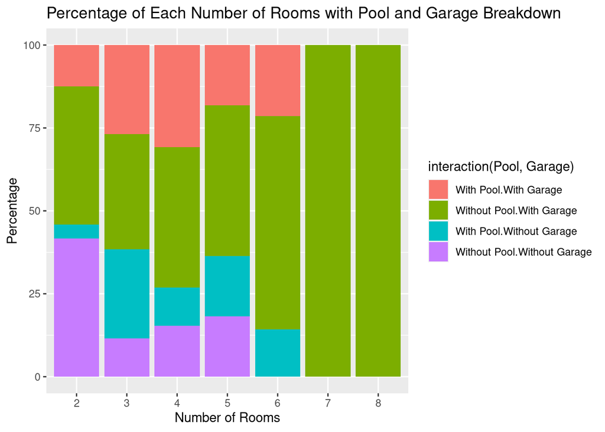

```r
# Create a stacked bar plot
ggplot(room_percentage, aes(x = factor(Bedrooms), y = Percentage, fill = interaction(Pool, Garage))) +
  geom_bar(stat = "identity") +
  labs(x = "Number of Rooms", y = "Percentage") +
  ggtitle("Percentage of Each Number of Rooms with Pool and Garage Breakdown")
```

From the graph we can notice that, those properties who have a lot of rooms, usually have garage.